# Bellabeat_Capstone_Project

Baraka Mtana

2024-10-30

## Important shortcuts we’ll reuse

#### Restart r = “Ctrl + Shift + F10”

#### %>% = “Ctrl + Shift + M”

#### New r line code = “Ctrl + Alt + I”

```r
#options(repos = c(CRAN = "https://cloud.r-project.org/"))
# Set up environment
# import libraries
library(tidyverse)
# install.packages("lubridate")
library(lubridate)
library(ggplot2)
library(dplyr)

#install.packages("plotly")
library(plotly)
# get and print working directory
currentDir <- getwd()
print(currentDir)
```

```
## [1] "C:/Users/LENOVO/Desktop/Bellabeat_Capstone-project"
```

```r
# list file in the working DIR
list.files(currentDir)
```

```
##  [1] "Bellabeat_Capstone-project.R"
##  [2] "Bellabeat_Capstone-project.Rproj"
##  [3] "BellabeatCapstoneProject.pdf"
##  [4] "BellabeatCapstoneProject.Rmd"
##  [5] "BellabeatCapstoneProject_files"
##  [6] "customer_averages.csv"
##  [7] "key_functions.R"
##  [8] "LICENSE"
##  [9] "mturkfitbit_export_3.12.16-4.11.16"
## [10] "README.md"
## [11] "Screenshot.png"
## [12] "UYTzmqN3SS-WCbei0buGkw_cbefaed7e1354ffb8e992c8e198906f1_Case-Study-2_-How-can-a-wellness-technology-company-play-it-smart-.pdf"
```

```r
# we are interested in the csv files in 'mturkfitbit_export_3.12.16-4.11.16'
# and 'Fitabase Data 3.12.16-4.11.16'
csv_files_Dir <- file.path(
  currentDir, 'mturkfitbit_export_3.12.16-4.11.16', 'Fitabase Data 3.12.16-4.11.16'
)

csv_files <- list.files(csv_files_Dir)
len_cvs = length(csv_files)

# csv_files <- list.files(csv_files_Dir, pattern = "\\.csv$", full.names = TRUE)
# print(csv_files)
```

```r
# Here we'll write function we'll reuse

# Check for missing values
missing_value <- function(df, file){

  # Initialize an empty list that will be a key value pair
  # It will hold df_name with missing values and the specific column with the missing values
  df_with_missing_values <- list()

  if (sum(is.na(df)) == 0){

    print(paste(file, "Has no missing values"))

  }else if (sum(is.na(df)) > 0){


    #append df_name with missing vales to df_with_missing_values
    df_with_missing_values[[file]] <- c() # initialize an empty vector to store
     #column names


    #get df columns with missing values
    colNames = colnames(df)

    for (col in colNames){
      if (sum(is.na(df[[col]]))  > 0){

        df_with_missing_values[[file]] <- c(df_with_missing_values[[file]], col)

        print(paste("Total missing values in", file, col, "is",
                    sum(is.na(df[col]))))
      }
    }

  }

  return(df_with_missing_values)
}



# get number of unique values
unique_value <- function(df, column_of_interest) {
  #get the unique values
  uniques <- unique(df[[column_of_interest]])

  # Get the unique values from the specified column
  n_unique <- length(uniques)

  print(paste(column_of_interest, "has",  n_unique, "values"))

}


# Let's check if we are dealing with the same clients
uniqueIDs_Comparison <- function (df1, column1, df2, column2){
  missing_ids = c()

  initial_list = unique(df1[[column1]])
  comparison_list = unique(df2[[column2]])


  for (i in initial_list){
    if (!(i %in% comparison_list)){
      missing_ids <- c(missing_ids, i)

    }
  }

  for (i in comparison_list){
    if (!(i %in% initial_list)){
      missing_ids <- c(missing_ids, i)

    }

  }

  if (length(missing_ids) == 0){
    print("Dataframes have similar values")


  }else{
    print("Dataframes have different values")
    print(paste("No. of missing values", length(unique(missing_ids))))
  }

  return(unique(missing_ids))
}


# Get the length of values in a column
N_unique_char <- function(df, column_of_interest){
  # Initialize/ pre-allocate a numeric vector of a specific length, initialized with   zeros
  n_char <- numeric(nrow(df))

  for (i in seq_along(df[[column_of_interest]])){
    n_char[i] <- nchar(df[[column_of_interest]][i])
  }

  # get the number of unique characters
  character_lens <- unique(n_char)

  return(character_lens)
}



change_to_dateTime <- function(df, column_of_interest){

  Values_Ncha_Column = N_unique_char(df, column_of_interest)

  #Check if all elements in the vector Values_Ncha_Column are either 8 or 9
  if (all(Values_Ncha_Column %in% c(8, 9))){
    df[[column_of_interest]] <-
      as.POSIXct(
        df[[column_of_interest]],
        format="%m/%d/%Y",
        tz=Sys.timezone()
    )

  }else if (!all(Values_Ncha_Column
                 %in% c(8, 9))){

    df[[column_of_interest]] <-
      as.POSIXct(
        df[[column_of_interest]],
        # %I: Hour (01–12, for 12-hour clock)
        # %p: AM/PM marker
        format = "%m/%d/%Y %I:%M:%S %p",
        tz=Sys.timezone()
    )
  }

  # confirm the datatype of the column of interest
  #print(paste(column_of_interest, "has" ,class(df[[column_of_interest]]),
              #"datatype"))

  print(head(df[column_of_interest], 5))
  print(tail(df[column_of_interest], 5))

  return(df)

}



# Check if the columns are identical
identical_columns <- function(df, col1, col2){
  if (identical(df[[col1]], df[[col2]])) {
    print("The columns are identical.")
  } else {
    print("The columns are NOT identical.")
  }
}



# Merge fucntion which we'll use with the reduce inbuilt function
merge_dfs <- function(df1, df2){
  merged_df <- merge(df1, df2, by = "Id")

  return(merged_df)
}

# calculate column averages
Avgs <- function(df, column_names_vector){

  # initialize and empty list
  column_Avgs = list()

  for (i in column_names_vector){
    # get the data of the column
    column_data <- df[, c("Id", i)]


    avg_per_athlete <- column_data %>%
      group_by(Id) %>%
      summarise(
        # use "get" to retrieves the variable from key which is i and
        # Rename the column_Avgs keys to avoid conflicts
        !!paste0("Avg_", i) := mean(get(i), na.rm = TRUE)
      )


    column_Avgs[[i]] = avg_per_athlete


  }

  # Merge DataFrames on the 'ID' column
  # How the reduce function works
  # 1.Reduce will take the first two data frames from column_Avgs and
  #pass them to merge_dfs.
  # 2. The result of the first merge will be passed as the first argument
  # to merge_dfs for the next data frame in the list, continuing this process until
  #all data frames have been merged.

  # Here the reduce function and
  merged_df <- Reduce(merge_dfs, column_Avgs)

  return(merged_df)
}


# line plot function
line_plot <- function(df, x_col, y_col){
  plot <- ggplot (data = df) +
    geom_line(mapping = aes(x= .data[[x_col]] , y= .data[[y_col]] )) +
    labs(title = paste(x_col, "and", y_col, "relationsip"))

  print(plot)

}

weekDate_grouping <- function(df, weekOrdate){
  # get group by the 1st 2 columns which will be "Id and column with POSIXct
  #datatype"
  grouping_Cols <- c(colnames(df)[1:2])
  summarise_Cols <- c(colnames(df)[-1:-2])

  # Check if the first column is "Id" and the second column is of type POSIXct
  if (grouping_Cols[1] == "Id" && inherits(df[[grouping_Cols[2]]], "POSIXct")){


    # Determine grouping based on the 'weekOrdate' parameter
    if(weekOrdate == "week"){
      # Group by week number
      df <- df %>%
        mutate(Group = format(.data[[grouping_Cols[2]]], "%Y-%U"))
    }else if(weekOrdate == "date"){
      df <- df %>%
        mutate(Group = as.Date(.data[[grouping_Cols[2]]]))
    }else {
      stop("Invalid string value for 'weekOrdate'. Use 'week' or 'date'.")
    }

    # If the above run successfully perform grouping and summarization
    df <- df %>%
      group_by(.data[[grouping_Cols[1]]], Group) %>%
      summarize(
        across(
          all_of(summarise_Cols),
          list(
            Total = ~sum(.x, na.rm = TRUE),
            Avg = ~mean(.x, na.rm = TRUE)
          ),
          #{col} acts as a Placeholder for the name of the original column being
          #processed
          #{fn}: Placeholder for the name of the function applied (e.g., "Total"
          #or "Avg").
          .names = "{col}_{fn}"
        ),
        .groups = "drop"
      )

  }else{
    stop("Please check the name and datatype of the 1st 2 columns.")
  }

  return(df)
}
```

```r
# Initialize an empty list to store data frames
dfs <- list()


for (file in csv_files) {

  print(paste("Working on", file))

  # create df names
  # split the file name str character
  df_name <- strsplit(file, split = '\\.')[[1]] #Access the first and only string

  # get the first part of the string character which is basically the name
  # without the csv extension
  df_name <- df_name[1]

  # concatenate the df_name with df
  df_name <- paste0(df_name, "_df") # Use paste0 for no space between parts

  # create full path for each file so that we can import them
  filepath <- file.path(csv_files_Dir, file)

  # read csv
  df <- read.csv(filepath)

  #Check if df has missing value
  missing_value(df = df, file = file)

  # append dfs and their names
  dfs[[df_name]] <- df  # Store the data frame in the list, keyed by file path

}
```

```
## [1] "Working on dailyActivity_merged.csv"
## [1] "dailyActivity_merged.csv Has no missing values"
## [1] "Working on heartrate_seconds_merged.csv"
## [1] "heartrate_seconds_merged.csv Has no missing values"
## [1] "Working on hourlyCalories_merged.csv"
## [1] "hourlyCalories_merged.csv Has no missing values"
## [1] "Working on hourlyIntensities_merged.csv"
## [1] "hourlyIntensities_merged.csv Has no missing values"
## [1] "Working on hourlySteps_merged.csv"
## [1] "hourlySteps_merged.csv Has no missing values"
## [1] "Working on minuteCaloriesNarrow_merged.csv"
## [1] "minuteCaloriesNarrow_merged.csv Has no missing values"
## [1] "Working on minuteIntensitiesNarrow_merged.csv"
## [1] "minuteIntensitiesNarrow_merged.csv Has no missing values"
## [1] "Working on minuteMETsNarrow_merged.csv"
## [1] "minuteMETsNarrow_merged.csv Has no missing values"
## [1] "Working on minuteSleep_merged.csv"
## [1] "minuteSleep_merged.csv Has no missing values"
## [1] "Working on minuteStepsNarrow_merged.csv"
## [1] "minuteStepsNarrow_merged.csv Has no missing values"
## [1] "Working on weightLogInfo_merged.csv"
## [1] "Total missing values in weightLogInfo_merged.csv Fat is 31"
```

```r
# Confirm that all df were read successfully
if (len_cvs == length(dfs)) {
  print("All files read successfully")
} else {
  print("Some files were not read correctly")
}
```

```
## [1] "All files read successfully"
```

```r
print(names(dfs))
```

```
##  [1] "dailyActivity_merged_df"           "heartrate_seconds_merged_df"
##  [3] "hourlyCalories_merged_df"          "hourlyIntensities_merged_df"
##  [5] "hourlySteps_merged_df"             "minuteCaloriesNarrow_merged_df"
##  [7] "minuteIntensitiesNarrow_merged_df" "minuteMETsNarrow_merged_df"
##  [9] "minuteSleep_merged_df"             "minuteStepsNarrow_merged_df"
## [11] "weightLogInfo_merged_df"
```

```r
dailyActivity_merged_df <-dfs[["dailyActivity_merged_df"]]
str(dailyActivity_merged_df)
```

```
## 'data.frame':    457 obs. of  15 variables:
##  $ Id                      : num  1.5e+09 1.5e+09 1.5e+09 1.5e+09 1.5e+09 ...
##  $ ActivityDate            : chr  "3/25/2016" "3/26/2016" "3/27/2016" "3/28/2016" ...
##  $ TotalSteps              : int  11004 17609 12736 13231 12041 10970 12256 12262 11248 10016 ...
##  $ TotalDistance           : num  7.11 11.55 8.53 8.93 7.85 ...
##  $ TrackerDistance         : num  7.11 11.55 8.53 8.93 7.85 ...
##  $ LoggedActivitiesDistance: num  0 0 0 0 0 0 0 0 0 0 ...
##  $ VeryActiveDistance      : num  2.57 6.92 4.66 3.19 2.16 ...
##  $ ModeratelyActiveDistance: num  0.46 0.73 0.16 0.79 1.09 ...
##  $ LightActiveDistance     : num  4.07 3.91 3.71 4.95 4.61 ...
##  $ SedentaryActiveDistance : num  0 0 0 0 0 0 0 0 0 0 ...
##  $ VeryActiveMinutes       : int  33 89 56 39 28 30 33 47 40 15 ...
##  $ FairlyActiveMinutes     : int  12 17 5 20 28 13 12 21 11 30 ...
##  $ LightlyActiveMinutes    : int  205 274 268 224 243 223 239 200 244 314 ...
##  $ SedentaryMinutes        : int  804 588 605 1080 763 1174 820 866 636 655 ...
##  $ Calories                : int  1819 2154 1944 1932 1886 1820 1889 1868 1843 1850 ...
```

```r
# we'll have a look at all unique value in if non of them is repeated
# change ActivityDate from character to datetime
# Assuming TotalSteps is cadence we'll see the average length of a step per person
# See if TotalDistance and TrackerDistance distance record the same data
# Calculate average TotalDistance, TrackerDistance, VeryActiveDistance,
# ModeratelyActiveDistance, LightActiveDistance, SedentaryActiveDistance,
# Average calories lost per day
```

check how many customers are we dealing with

```r
# call function on dailyActivity_merged_df
unique_value(dailyActivity_merged_df, "Id")
```

```
## [1] "Id has 35 values"
```

See the number of character in each character of the ActivityDate column since we’ve already seen there are inconsistencies in the ActivityDate, –> let’s see if there are some date characters saved with hrs,min,and secs

```r
# see if there is uniformity in the Activity date column
N_unique_char(dailyActivity_merged_df, "ActivityDate")
```

```
## [1] 9 8
```

```r
# call change_to_date on dailyActivity_merged_df
dailyActivity_merged_df <- change_to_dateTime(dailyActivity_merged_df,
                                              "ActivityDate")
```

```
##   ActivityDate
## 1   2016-03-25
## 2   2016-03-26
## 3   2016-03-27
## 4   2016-03-28
## 5   2016-03-29
##     ActivityDate
## 453   2016-04-08
## 454   2016-04-09
## 455   2016-04-10
## 456   2016-04-11
## 457   2016-04-12
```

```r
# call identical_columns on dailyActivity_merged_df
identical_columns(dailyActivity_merged_df, "TotalDistance", "TrackerDistance" )
```

```
## [1] "The columns are NOT identical."
```

```r
# Call the Avgs function to get the averages of some columns in dailyActivity_merged_df

column_names <- c(names(dailyActivity_merged_df)[3:10], tail(names(dailyActivity_merged_df), 1))

averages_df = Avgs(dailyActivity_merged_df, column_names)

# Write the data frame to a CSV file
# write.csv(averages_df, file = "customer_averages.csv", row.names = FALSE)
```

```r
averages_df
```

```
##            Id Avg_TotalSteps Avg_TotalDistance Avg_TrackerDistance
## 1  1503960366      11640.526          7.607368           7.6073685
## 2  1624580081       4226.263          2.746842           2.7468421
## 3  1644430081       9274.800          6.749000           6.7490000
## 4  1844505072       3640.583          2.406667           2.4066667
## 5  1927972279       2180.833          1.510833           1.5108333
## 6  2022484408      12174.917          8.774167           8.7741668
## 7  2026352035       3392.750          2.103333           2.1033333
## 8  2320127002       3138.417          2.122500           2.1225000
## 9  2347167796       9800.067          6.511333           6.5113334
## 10 2873212765       6636.583          4.469167           4.4691667
## 11 2891001357        773.625          0.603750           0.0000000
## 12 3372868164       6127.500          4.216000           4.2160000
## 13 3977333714       8663.917          5.806667           5.8066666
## 14 4020332650       5776.594          4.143750           4.1437500
```

[output cut: 129 more lines]

Check the correlation between TotalDistance and Calories

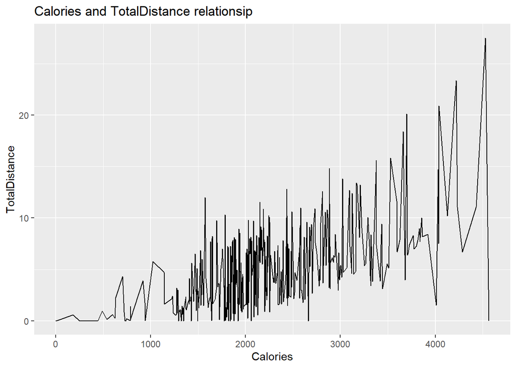

```r
# call function on dailyActivity_merged_df
line_plot(df = dailyActivity_merged_df, x_col= "Calories", y_col = "TotalDistance")
```

## Let’s get to see heartrate_seconds_merged_df

```r
heartrate_seconds_merged_df <- dfs[["heartrate_seconds_merged_df"]]
str(heartrate_seconds_merged_df)
```

```
## 'data.frame':    1154681 obs. of  3 variables:
##  $ Id   : num  2.02e+09 2.02e+09 2.02e+09 2.02e+09 2.02e+09 ...
##  $ Time : chr  "4/1/2016 7:54:00 AM" "4/1/2016 7:54:05 AM" "4/1/2016 7:54:10 AM" "4/1/2016 7:54:15 AM" ...
##  $ Value: int  93 91 96 98 100 101 104 105 102 106 ...
```

```r
head(heartrate_seconds_merged_df, 5)
```

```
##           Id                Time Value
## 1 2022484408 4/1/2016 7:54:00 AM    93
## 2 2022484408 4/1/2016 7:54:05 AM    91
## 3 2022484408 4/1/2016 7:54:10 AM    96
## 4 2022484408 4/1/2016 7:54:15 AM    98
## 5 2022484408 4/1/2016 7:54:20 AM   100
```

```r
tail(heartrate_seconds_merged_df, 5)
```

```
##                 Id                 Time Value
## 1154677 8877689391 4/12/2016 9:46:25 AM   113
## 1154678 8877689391 4/12/2016 9:46:30 AM   108
## 1154679 8877689391 4/12/2016 9:46:35 AM   102
## 1154680 8877689391 4/12/2016 9:46:40 AM    99
## 1154681 8877689391 4/12/2016 9:46:45 AM    98
```

```r
# Check if the unique Ids are similar to the ones in dailyActivity_merged_df
# change time column to datetime
# see the average heart rate per unique id, see the correlation between the average heart rate and calories lost
# see if there is any negative hr values
```

Confirm if we are dealing with the same atheletes. Check if the unique Ids are similar to the ones in dailyActivity_merged_df

```r
IDs <- uniqueIDs_Comparison(df1 = dailyActivity_merged_df, column1 = "Id", df2 = heartrate_seconds_merged_df, column2 = "Id")
```

```
## [1] "Dataframes have different values"
## [1] "No. of missing values 21"
```

These means we we are only dealing with 14 clients in both dailyActivity_merged_df, and heartrate_seconds_merged_df dataframes.

```r
print(IDs)
```

```
##  [1] 1503960366 1624580081 1644430081 1844505072 1927972279 2320127002
##  [7] 2873212765 2891001357 3372868164 3977333714 4057192912 4319703577
## [13] 4388161847 4445114986 4702921684 6290855005 7086361926 8053475328
## [19] 8253242879 8378563200 8583815059
```

Change the time columns to datetime

```r
heartrate_seconds_merged_df <- change_to_dateTime(heartrate_seconds_merged_df, "Time")
```

```
##                  Time
## 1 2016-04-01 07:54:00
## 2 2016-04-01 07:54:05
## 3 2016-04-01 07:54:10
## 4 2016-04-01 07:54:15
## 5 2016-04-01 07:54:20
##                        Time
## 1154677 2016-04-12 09:46:25
## 1154678 2016-04-12 09:46:30
## 1154679 2016-04-12 09:46:35
## 1154680 2016-04-12 09:46:40
## 1154681 2016-04-12 09:46:45
```

see the average heart rate per unique id, see the correlation between the average heart rate and calories lost

```r
# calculate averages
average_hr <- function(df, column_calculate_avg){
  averages_hr_per_athlete <- df %>%
    group_by(Id)  %>%
      summarise(
        Avg_Hr = mean(column_calculate_avg),
    )

  print(head(averages_per_athlete, 5))
}
```

```r
average_hr_per_athlete <- Avgs(heartrate_seconds_merged_df, c(names(heartrate_seconds_merged_df)[3]))


new_col_name = names(average_hr_per_athlete)[2]

print(average_hr_per_athlete)
```

```
## # A tibble: 14 × 2
##            Id Avg_Value
##         <dbl>     <dbl>
##  1 2022484408      81.7
##  2 2026352035      65.8
##  3 2347167796      76.1
##  4 4020332650      81.9
##  5 4558609924      79.6
##  6 5553957443      69.4
##  7 5577150313      65.0
##  8 6117666160      83.5
##  9 6391747486      84.1
## 10 6775888955      97.7
## 11 6962181067      80.7
## 12 7007744171      89.9
## 13 8792009665      76.3
## 14 8877689391      87.6
```

```r
print(max(average_hr_per_athlete[[new_col_name]]))
```

```
## [1] 97.73704
```

```r
print(min(average_hr_per_athlete[[new_col_name]]))
```

```
## [1] 65.00254
```

```r
print(median(ceiling(average_hr_per_athlete[[new_col_name]]), na.rm = TRUE))
```

```
## [1] 81.5
```

```r
(mean(ceiling(average_hr_per_athlete[[new_col_name]])))
```

```
## [1] 80.42857
```

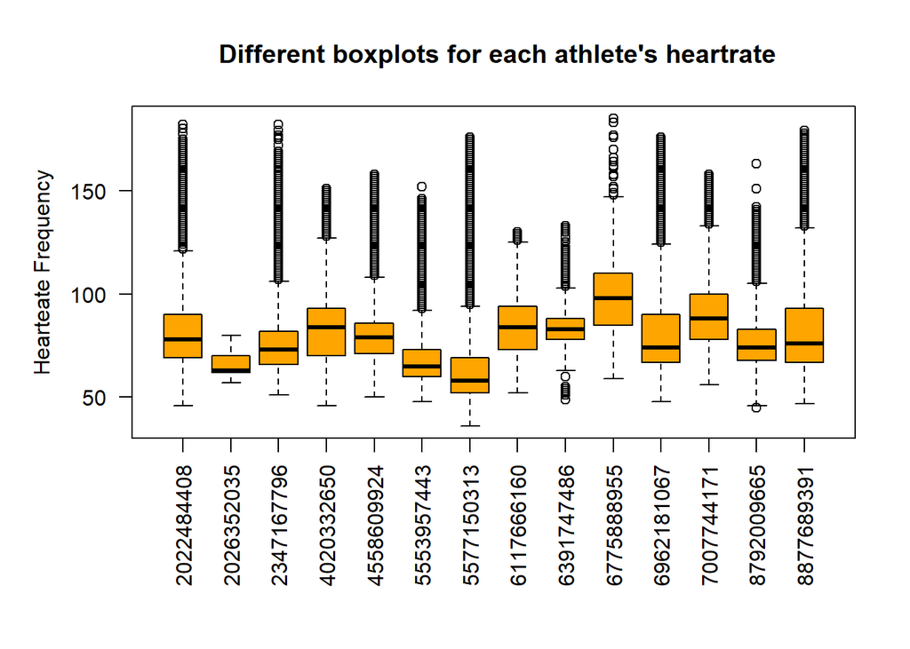

```r
# Increase bottom margin to fit x-axis labels better
par(mar = c(8, 5, 4, 2) + 0.1)


boxplot(Value ~ Id,
        data = heartrate_seconds_merged_df,
        main =" Different boxplots for each athlete's heartrate",
        xlab = " ",
        ylab = "Hearteate Frequency",
        col = "orange",
        #main = "Perpendicular",
        las = 2
        #horizontal = TRUE
        #border="brown"
)
```

#### Here we’ll analyse hourlyCalories_merged_df

```r
hourlyCalories_merged_df <- dfs[['hourlyCalories_merged_df']]
str(hourlyCalories_merged_df)
```

```
## 'data.frame':    24084 obs. of  3 variables:
##  $ Id          : num  1.5e+09 1.5e+09 1.5e+09 1.5e+09 1.5e+09 ...
##  $ ActivityHour: chr  "3/12/2016 12:00:00 AM" "3/12/2016 1:00:00 AM" "3/12/2016 2:00:00 AM" "3/12/2016 3:00:00 AM" ...
##  $ Calories    : int  48 48 48 48 48 48 48 48 48 49 ...
```

```r
# Check if the unique Ids are similar to the ones in heartrate_seconds_merged_df
# see average calories lost each hour.
# Check which our are people most active
# change ActivityHour to datetime
```

```r
# Check if the unique Ids are similar to the ones in dailyActivity_merged_df
uniqueIDs_Comparison(dailyActivity_merged_df, "Id",  hourlyCalories_merged_df, "Id")
```

```
## [1] "Dataframes have different values"
## [1] "No. of missing values 1"
```

```
## [1] 4388161847
```

```r
# Change to datetime
hourlyCalories_merged_df <-  change_to_dateTime(hourlyCalories_merged_df, "ActivityHour")
```

```
##          ActivityHour
## 1 2016-03-12 00:00:00
## 2 2016-03-12 01:00:00
## 3 2016-03-12 02:00:00
## 4 2016-03-12 03:00:00
## 5 2016-03-12 04:00:00
##              ActivityHour
## 24080 2016-04-12 04:00:00
## 24081 2016-04-12 05:00:00
## 24082 2016-04-12 06:00:00
## 24083 2016-04-12 07:00:00
## 24084 2016-04-12 08:00:00
```

```r
hourlyIntensities_merged_df <- dfs[["hourlyIntensities_merged_df"]]
str(hourlyIntensities_merged_df)
```

```
## 'data.frame':    24084 obs. of  4 variables:
##  $ Id              : num  1.5e+09 1.5e+09 1.5e+09 1.5e+09 1.5e+09 ...
##  $ ActivityHour    : chr  "3/12/2016 12:00:00 AM" "3/12/2016 1:00:00 AM" "3/12/2016 2:00:00 AM" "3/12/2016 3:00:00 AM" ...
##  $ TotalIntensity  : int  0 0 0 0 0 0 0 0 0 1 ...
##  $ AverageIntensity: num  0 0 0 0 0 ...
```

```r
# Check if the unique Ids are similar to the ones in dailyActivity_merged_df
# and hourlyCalories_merged_df and hourlyCalories_merged_df since they have similar number row
# merge with hourlyCalories_merged_df see intensity and calories correlation on the same plot
# see AverageIntensity and Calories corelaion
```

```r
# See head and tail
head(hourlyIntensities_merged_df, 5)
```

```
##           Id          ActivityHour TotalIntensity AverageIntensity
## 1 1503960366 3/12/2016 12:00:00 AM              0                0
## 2 1503960366  3/12/2016 1:00:00 AM              0                0
## 3 1503960366  3/12/2016 2:00:00 AM              0                0
## 4 1503960366  3/12/2016 3:00:00 AM              0                0
## 5 1503960366  3/12/2016 4:00:00 AM              0                0
```

```r
#print(tail(hourlyIntensities_merged_df), 5)
```

```r
column1 = "Id"
column2 = "Id"
uniqueIDs_Comparison(hourlyCalories_merged_df, column1,
                     hourlyIntensities_merged_df,
                     column2)
```

```
## [1] "Dataframes have similar values"
```

```r
hourlyIntensities_merged_df <- change_to_dateTime(hourlyIntensities_merged_df, "ActivityHour")
```

```
##          ActivityHour
## 1 2016-03-12 00:00:00
## 2 2016-03-12 01:00:00
## 3 2016-03-12 02:00:00
## 4 2016-03-12 03:00:00
## 5 2016-03-12 04:00:00
##              ActivityHour
## 24080 2016-04-12 04:00:00
## 24081 2016-04-12 05:00:00
## 24082 2016-04-12 06:00:00
## 24083 2016-04-12 07:00:00
## 24084 2016-04-12 08:00:00
```

```r
# confirm that the ActivityHour in both hourlyCalories_merged_df and hourlyIntensities_merged_df are similar
column1 = "ActivityHour"
column2 = "ActivityHour"
non_unifom_dates =uniqueIDs_Comparison(hourlyCalories_merged_df, column1,
                     hourlyIntensities_merged_df,column2)
```

```
## [1] "Dataframes have similar values"
```

```r
head_values <-  (head(non_unifom_dates, 5))
tail_values <- (tail(non_unifom_dates, 5))

print(head_values)
```

[output not shown]

```r
print(tail_values)
```

[output not shown]

```r
# Join dataframes
CaloriesIntensities_df <- hourlyCalories_merged_df%>%inner_join(hourlyIntensities_merged_df,
                              by=c('Id','ActivityHour'))


head(CaloriesIntensities_df, 5)
```

```
##           Id        ActivityHour Calories TotalIntensity AverageIntensity
## 1 1503960366 2016-03-12 00:00:00       48              0                0
## 2 1503960366 2016-03-12 01:00:00       48              0                0
## 3 1503960366 2016-03-12 02:00:00       48              0                0
## 4 1503960366 2016-03-12 03:00:00       48              0                0
## 5 1503960366 2016-03-12 04:00:00       48              0                0
```

```r
if(nrow(hourlyCalories_merged_df) == nrow(CaloriesIntensities_df) &&
   (nrow(hourlyCalories_merged_df) == nrow(hourlyIntensities_merged_df))){

  print("Dataframes have same number of rows")

}
```

```
## [1] "Dataframes have same number of rows"
```

```r
hourlySteps_merged_df <- dfs[["hourlySteps_merged_df"]]
str(hourlySteps_merged_df)
```

```
## 'data.frame':    24084 obs. of  3 variables:
##  $ Id          : num  1.5e+09 1.5e+09 1.5e+09 1.5e+09 1.5e+09 ...
##  $ ActivityHour: chr  "3/12/2016 12:00:00 AM" "3/12/2016 1:00:00 AM" "3/12/2016 2:00:00 AM" "3/12/2016 3:00:00 AM" ...
##  $ StepTotal   : int  0 0 0 0 0 0 0 0 0 8 ...
```

```r
# Check if the unique Ids are similar to the ones in hourlyCalories_merged_df
# merge with  hourlyCalories_merged_df
# see the at what time are people most active
# see correlation between steps and calories
```

```r
hourlySteps_merged_df <- change_to_dateTime(hourlySteps_merged_df, "ActivityHour")
```

```
##          ActivityHour
## 1 2016-03-12 00:00:00
## 2 2016-03-12 01:00:00
## 3 2016-03-12 02:00:00
## 4 2016-03-12 03:00:00
## 5 2016-03-12 04:00:00
##              ActivityHour
## 24080 2016-04-12 04:00:00
## 24081 2016-04-12 05:00:00
## 24082 2016-04-12 06:00:00
## 24083 2016-04-12 07:00:00
## 24084 2016-04-12 08:00:00
```

```r
CaloriesIntensitiesSteps_df <- CaloriesIntensities_df%>%inner_join(
  hourlySteps_merged_df, by=c('Id', 'ActivityHour'))

head(CaloriesIntensitiesSteps_df, 5)
```

```
##           Id        ActivityHour Calories TotalIntensity AverageIntensity
## 1 1503960366 2016-03-12 00:00:00       48              0                0
## 2 1503960366 2016-03-12 01:00:00       48              0                0
## 3 1503960366 2016-03-12 02:00:00       48              0                0
## 4 1503960366 2016-03-12 03:00:00       48              0                0
## 5 1503960366 2016-03-12 04:00:00       48              0                0
##   StepTotal
## 1         0
## 2         0
## 3         0
## 4         0
## 5         0
```

```r
if(nrow(CaloriesIntensitiesSteps_df) == nrow(CaloriesIntensities_df) &&
   (nrow(CaloriesIntensitiesSteps_df) == nrow(hourlySteps_merged_df))){

  print("Dataframes have same number of rows")

}
```

```
## [1] "Dataframes have same number of rows"
```

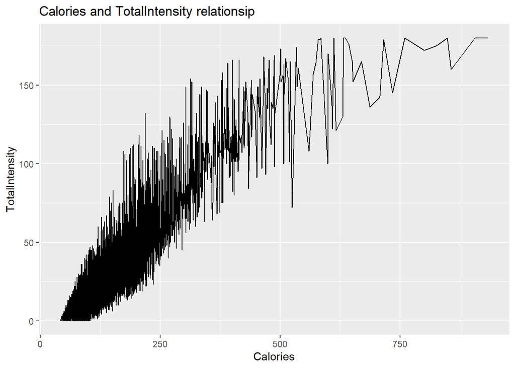

```r
# plot a line plot see see the correlation between calories, intensity and steps
line_plot(CaloriesIntensitiesSteps_df, "Calories", "TotalIntensity")
```

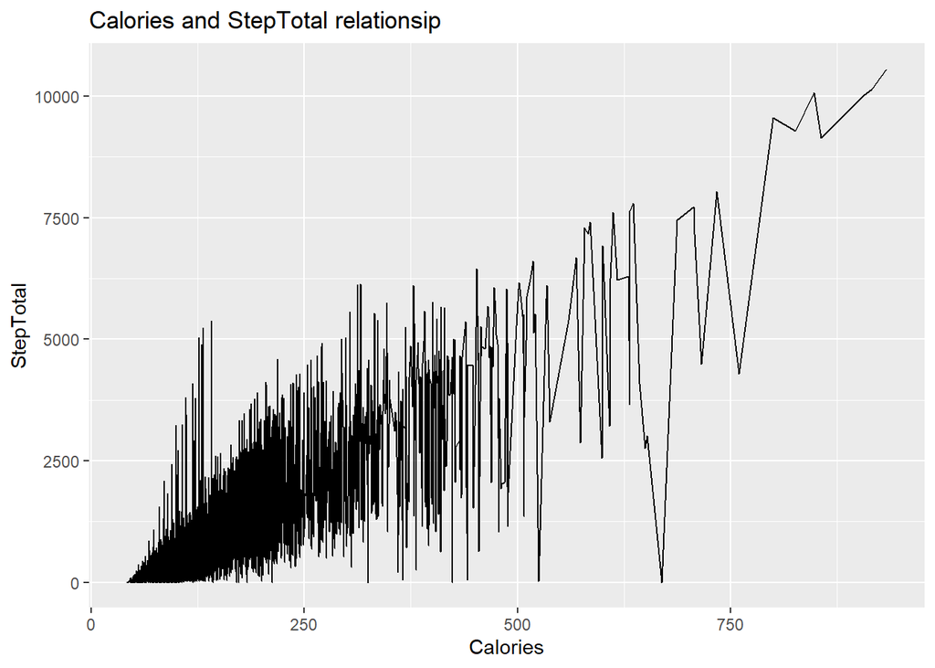

```r
line_plot(CaloriesIntensitiesSteps_df, "Calories", "StepTotal")
```

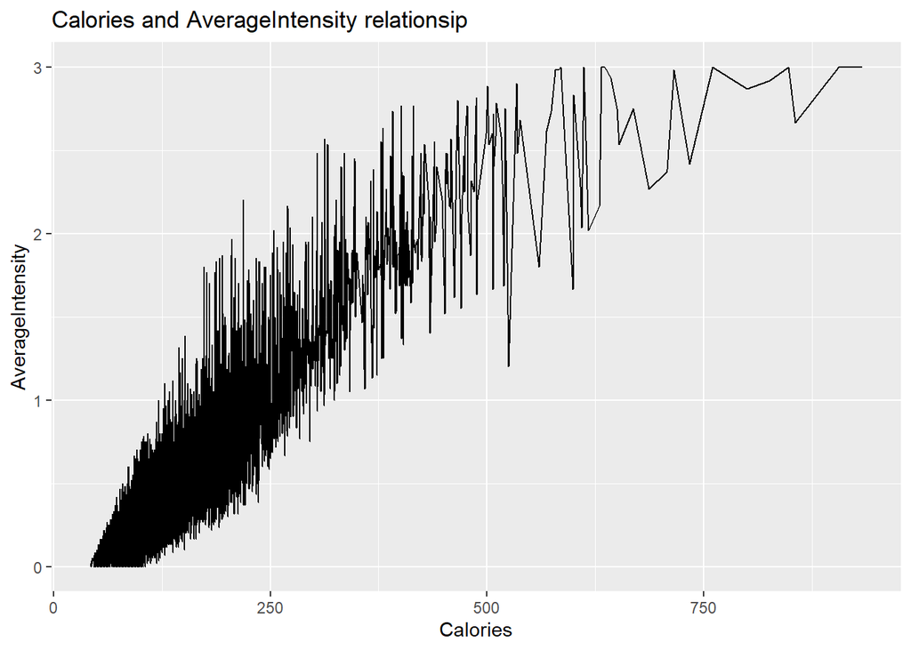

```r
line_plot(CaloriesIntensitiesSteps_df, "Calories", "AverageIntensity")
```

```r
colnames(CaloriesIntensitiesSteps_df)
```

```
## [1] "Id"               "ActivityHour"     "Calories"         "TotalIntensity"
## [5] "AverageIntensity" "StepTotal"
```

```r
custom_line_plot <- function(df, x_col, y_col, i){
    plot <- ggplot (data = df) +
      geom_line(mapping = aes(x= .data[[x_col]] , y= .data[[y_col]] )) +
      labs(title = paste(i, x_col, "and", y_col, "relationsip"))

  print(plot)

}
```

```r
CaloriesIntensitiesSteps_Daily_df <- weekDate_grouping(CaloriesIntensitiesSteps_df,
                                                       "date")
CaloriesIntensitiesSteps_Daily_df
```

```
## # A tibble: 1,053 × 10
##            Id Group      Calories_Total Calories_Avg TotalIntensity_Total
##         <dbl> <date>              <int>        <dbl>                <int>
##  1 1503960366 2016-03-11            144         48                      0
##  2 1503960366 2016-03-12           2237         93.2                  600
##  3 1503960366 2016-03-13           2106         87.8                  560
##  4 1503960366 2016-03-14           1836         76.5                  371
##  5 1503960366 2016-03-15           2092         87.2                  487
##  6 1503960366 2016-03-16           1990         82.9                  446
##  7 1503960366 2016-03-17           2052         85.5                  441
##  8 1503960366 2016-03-18           1973         82.2                  400
##  9 1503960366 2016-03-19           2065         86.0                  475
## 10 1503960366 2016-03-20           2089         87.0                  459
## # ℹ 1,043 more rows
## # ℹ 5 more variables: TotalIntensity_Avg <dbl>, AverageIntensity_Total <dbl>,
## #   AverageIntensity_Avg <dbl>, StepTotal_Total <int>, StepTotal_Avg <dbl>
```

```r
names(CaloriesIntensitiesSteps_Daily_df)
```

```
##  [1] "Id"                     "Group"                  "Calories_Total"
##  [4] "Calories_Avg"           "TotalIntensity_Total"   "TotalIntensity_Avg"
##  [7] "AverageIntensity_Total" "AverageIntensity_Avg"   "StepTotal_Total"
## [10] "StepTotal_Avg"
```

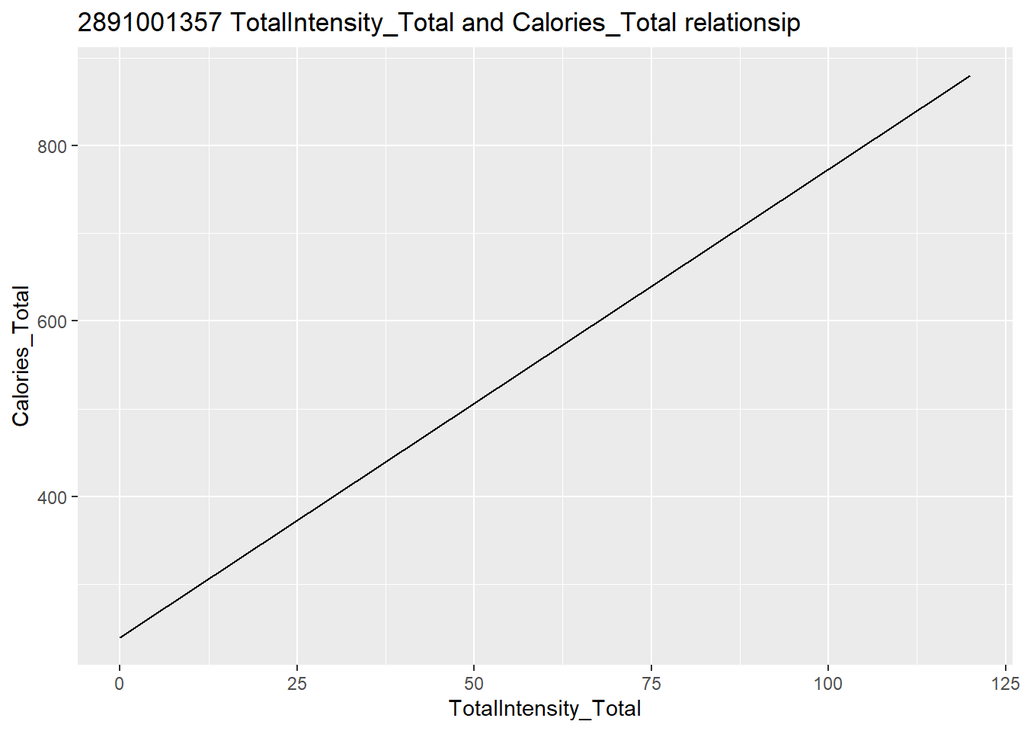

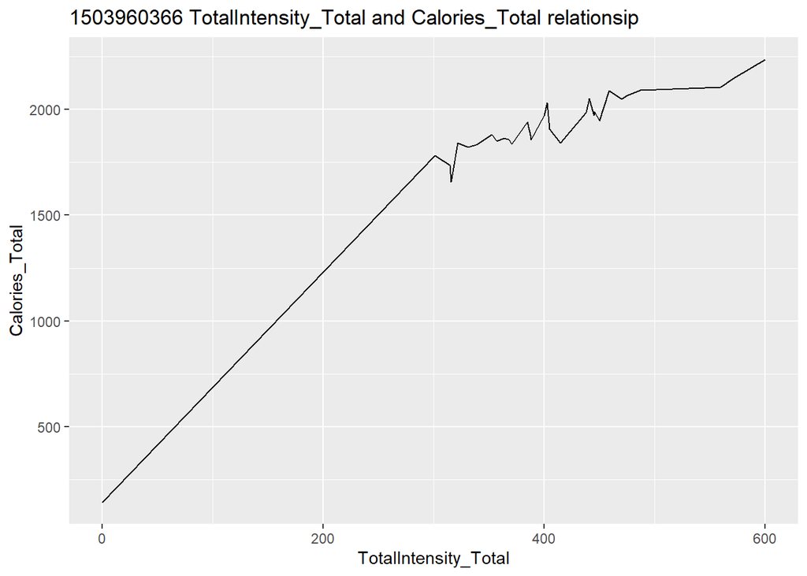

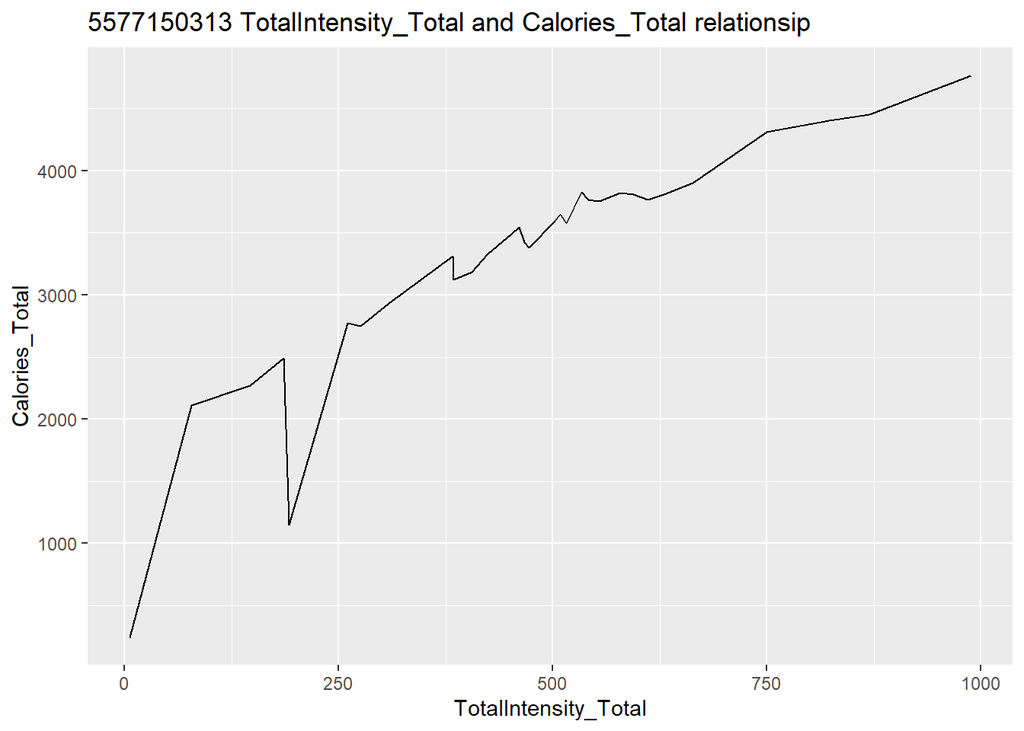

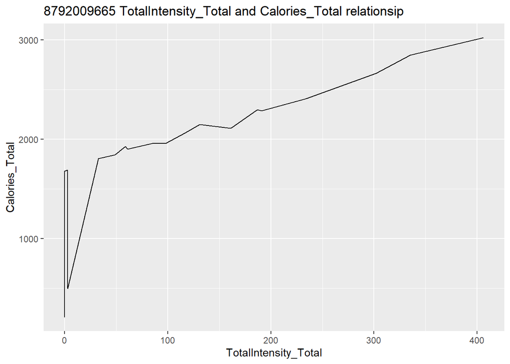

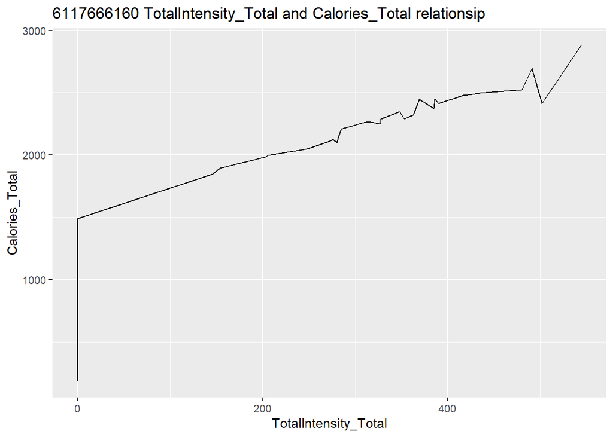

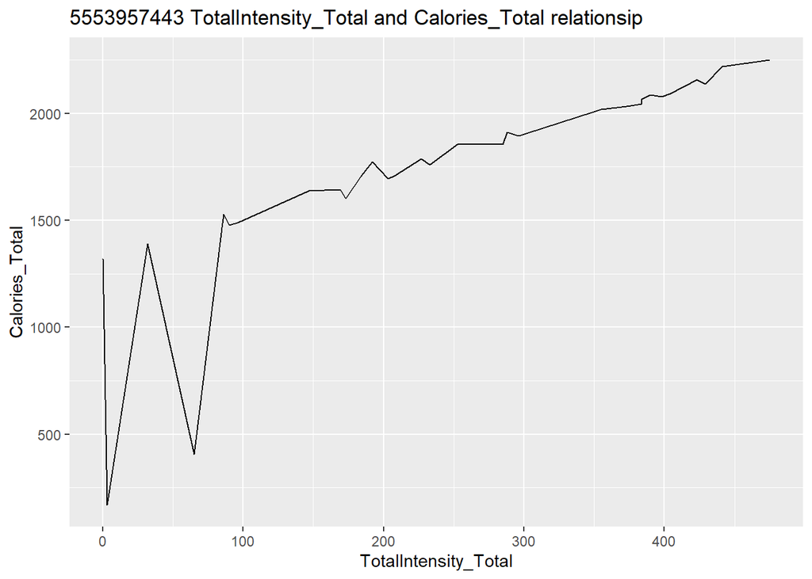

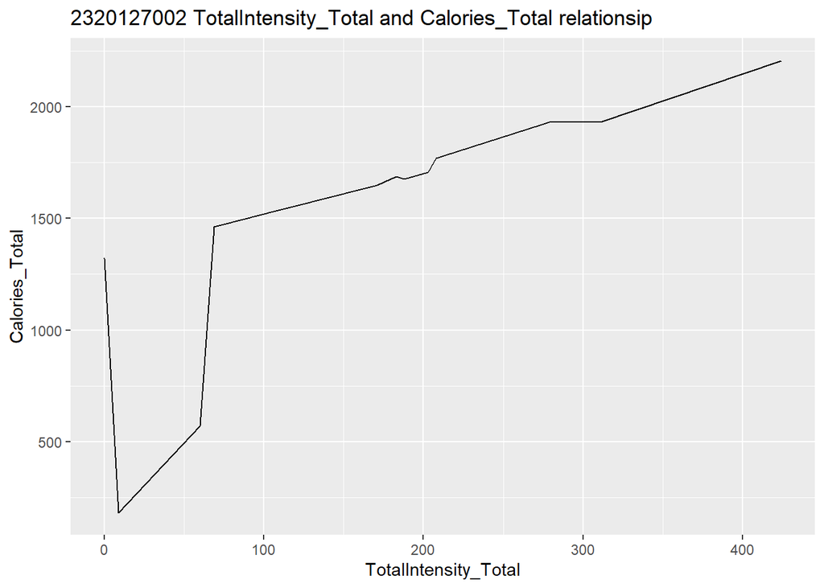

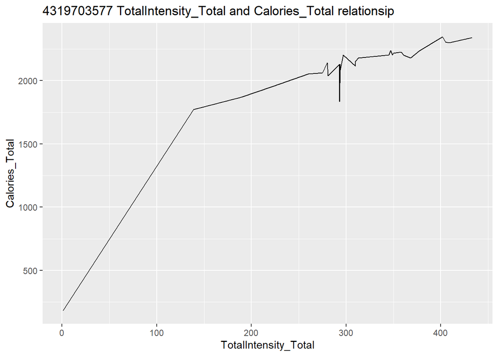

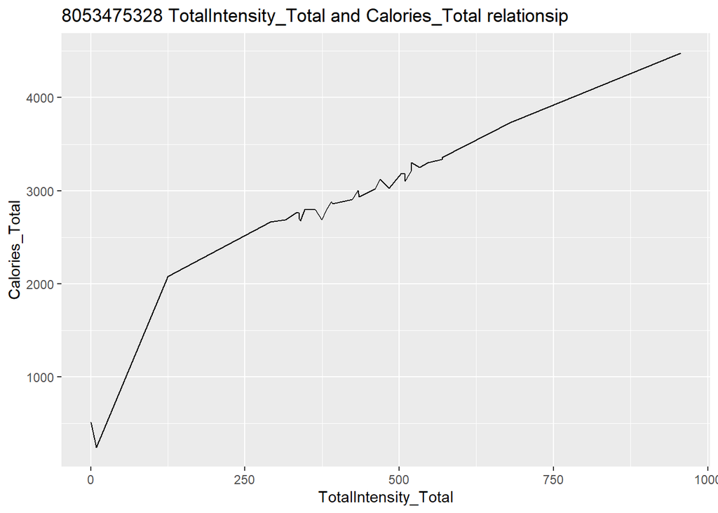

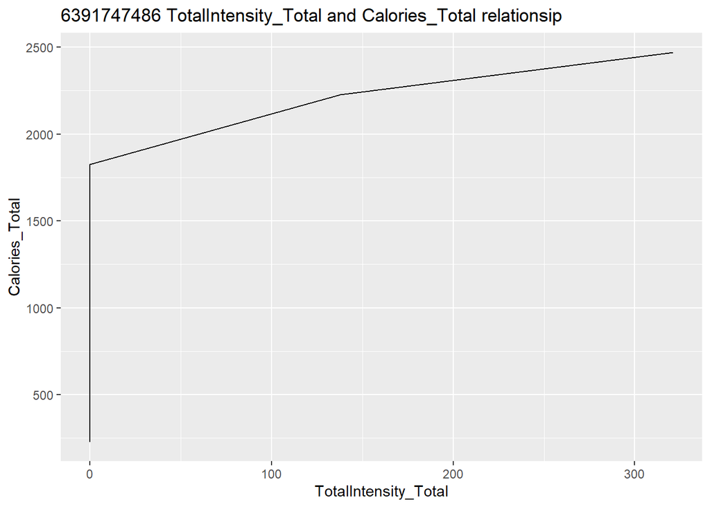

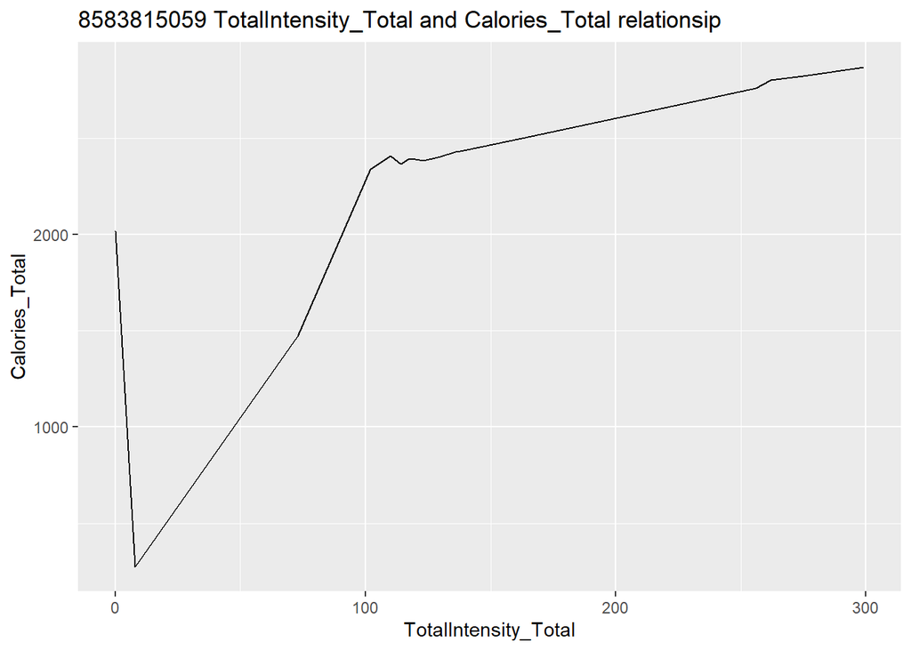

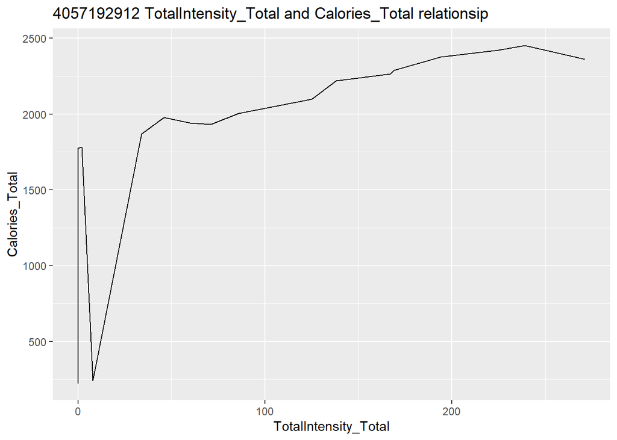

[3 more figures not shown]

```r
IDS <- c(unique(CaloriesIntensitiesSteps_Daily_df[["Id"]]))

random_Ids = IDS[ceiling(runif((ceiling(length(IDS)*0.5)), max = length(IDS)))]

for (i in random_Ids){
  filtered_df <- CaloriesIntensitiesSteps_Daily_df %>%
    filter(Id == i)

  custom_line_plot(filtered_df,
            "TotalIntensity_Total","Calories_Total",i
  )
}
```

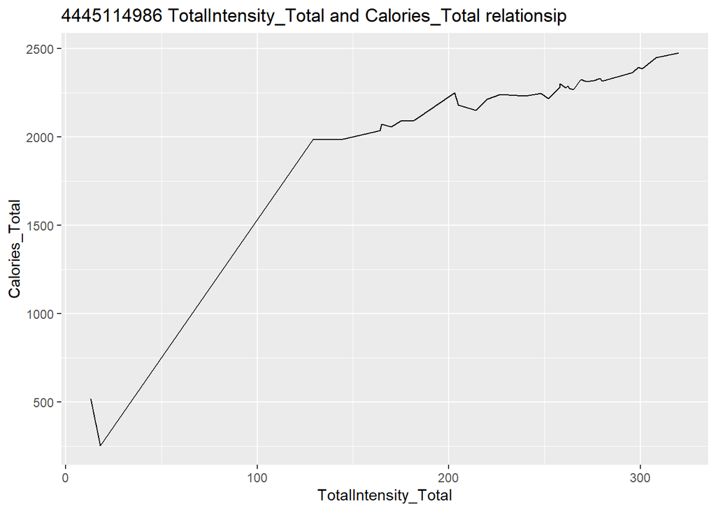

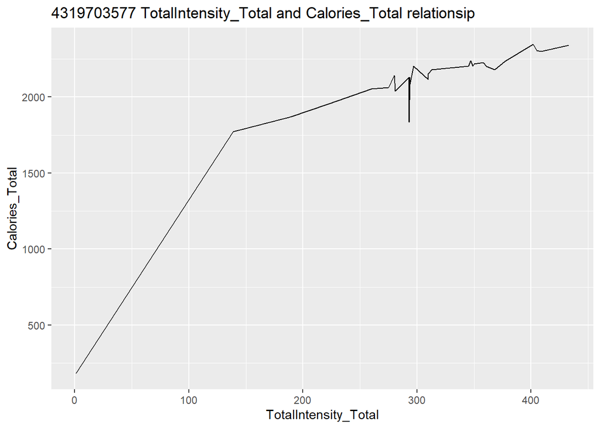

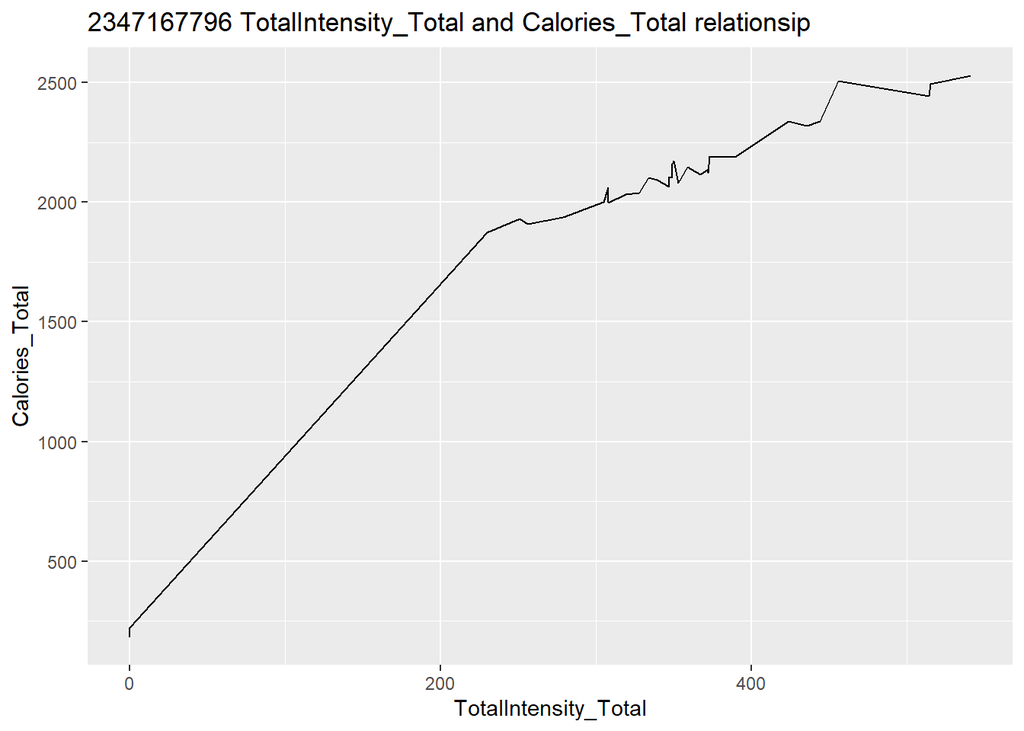

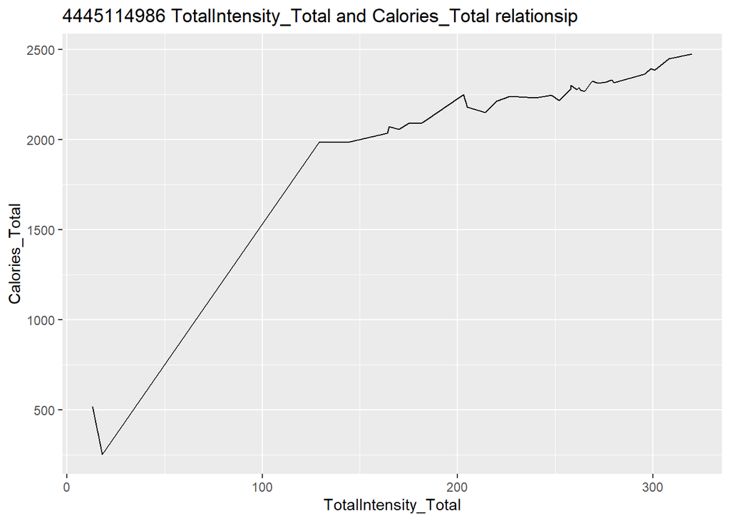

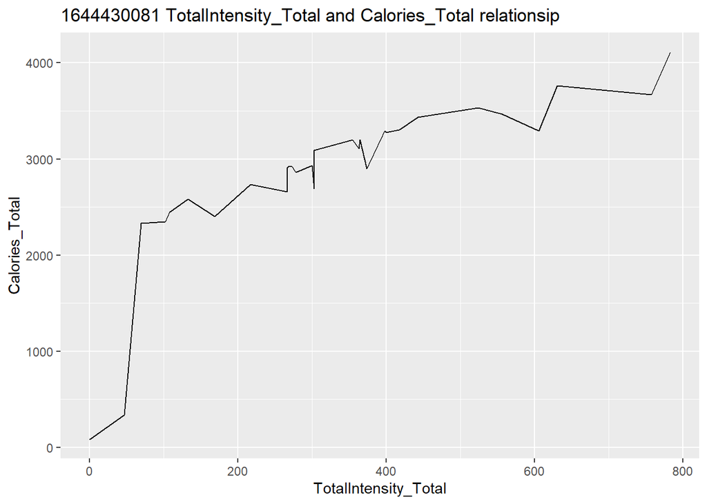

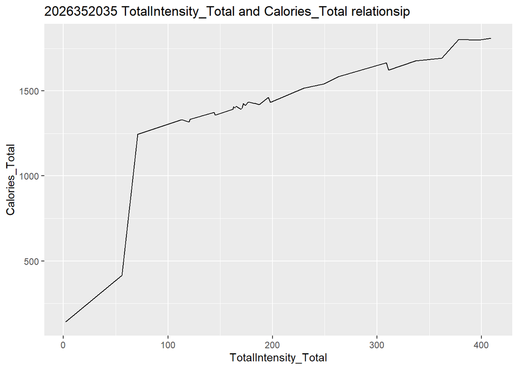

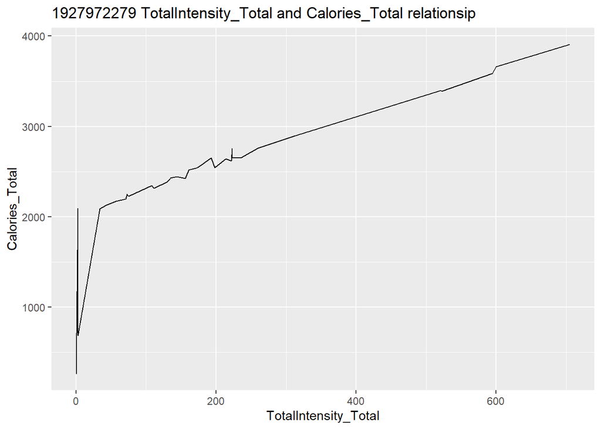

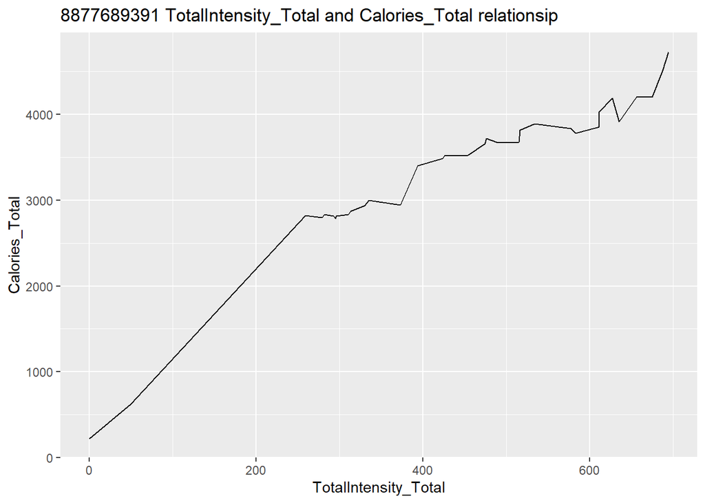

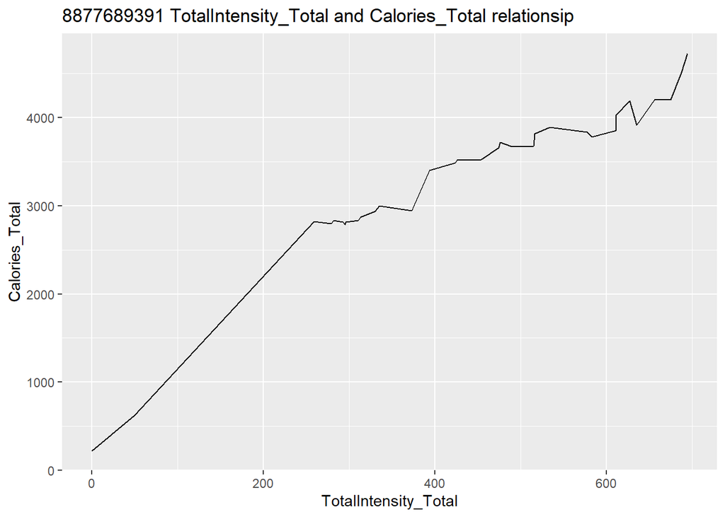

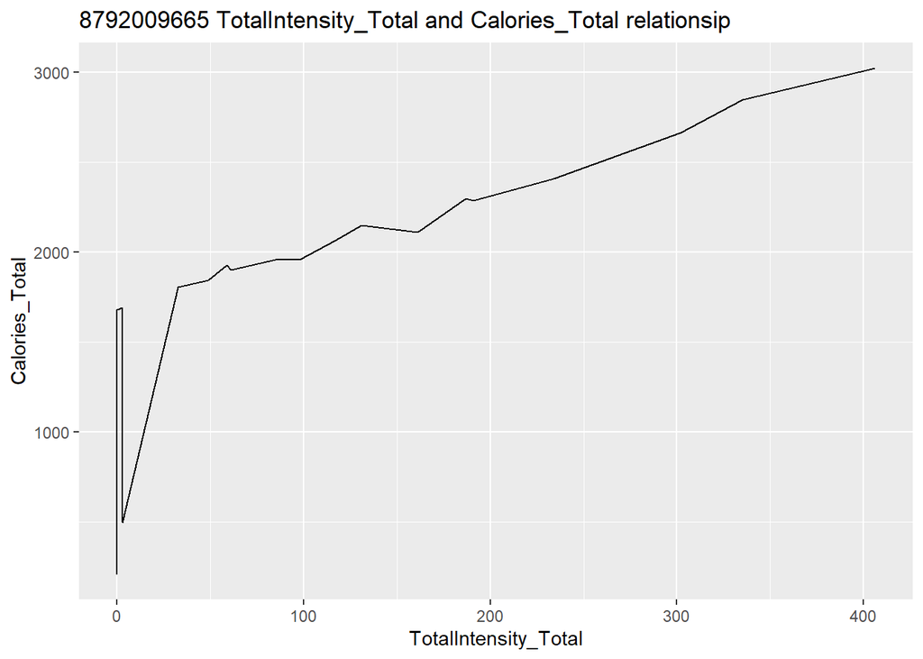

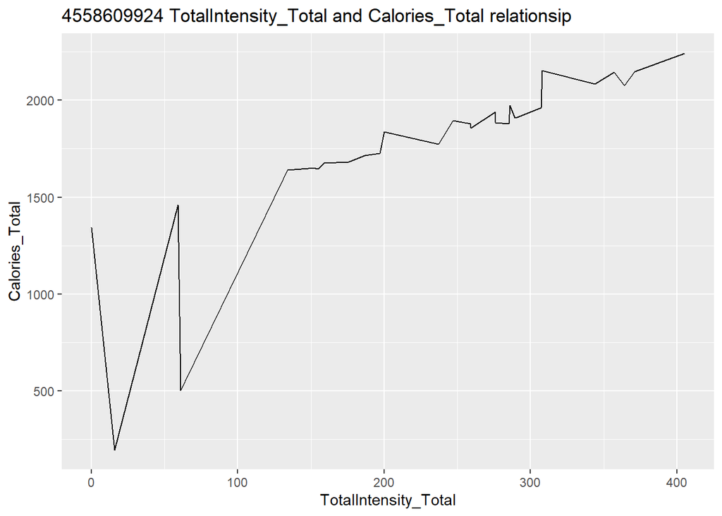

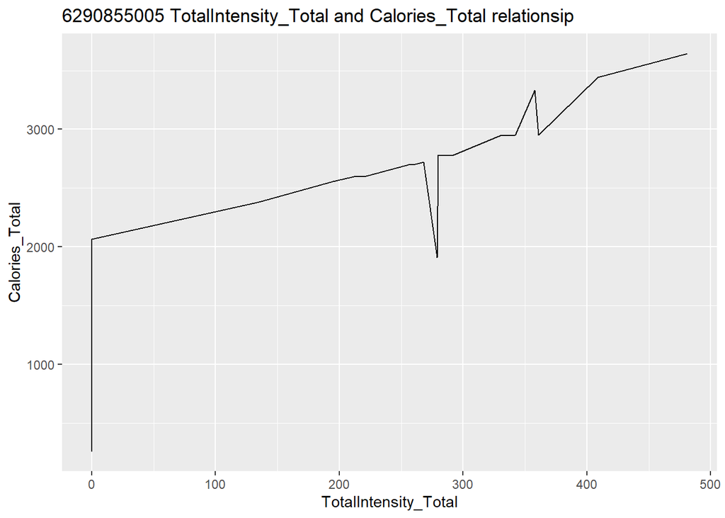

[4 more figures not shown]

```r
IDS <- c(unique(CaloriesIntensitiesSteps_Daily_df[["Id"]]))

random_Ids = IDS[ceiling(runif((ceiling(length(IDS)*0.5)), max = length(IDS)))]

for (i in random_Ids){
  filtered_df <- CaloriesIntensitiesSteps_Daily_df %>%
    filter(Id == i)

  custom_line_plot(filtered_df,
            "TotalIntensity_Total","Calories_Total",i
  )
}
```

```r
CaloriesIntensitiesSteps_Weekly_df <-
  weekDate_grouping(CaloriesIntensitiesSteps_df, "week")
head(CaloriesIntensitiesSteps_Weekly_df, 5)
```

```
## # A tibble: 5 × 10
##           Id Group   Calories_Total Calories_Avg TotalIntensity_Total
##        <dbl> <chr>            <int>        <dbl>                <int>
## 1 1503960366 2016-10           2228         92.8                  596
## 2 1503960366 2016-11          14106         84.0                 3177
## 3 1503960366 2016-12          13886         82.7                 2986
## 4 1503960366 2016-13          13179         78.4                 2680
## 5 1503960366 2016-14          13358         79.5                 2741
## # ℹ 5 more variables: TotalIntensity_Avg <dbl>, AverageIntensity_Total <dbl>,
## #   AverageIntensity_Avg <dbl>, StepTotal_Total <int>, StepTotal_Avg <dbl>
```